# Tianjin

Caroline Colijn

25/02/2020

## Data

Thanks to Dongxuan Chen and Louxin Zhang. These data are from three main sources:

- source1: http://wsjk.tj.gov.cn/col/col87/index.html#!uid=259&pageNum=1 (Tianjin health commission official website, for daily announcements)
- source2: https://weibo.com/u/2967529507 (Jinyun News, Tianjin offical local media weibo account, for patient symptom onset reference)
- source3: https://m.weibo.cn/status/IrrHI1FHm?jumpfrom=weibocom (another Tianjin local media weibo link, for mall cluster reference)

```r
tdata=read.csv("Tianjin135casesFeb22.csv",na.strings = "", stringsAsFactors = F)
tdata$symptom_onset=as.Date(tdata$symptom_onset, format = "%d/%m/%Y")
tdata$start_source=as.Date(tdata$start_source, format = "%d/%m/%Y")
tdata$end_source=as.Date(tdata$end_source,format = "%d/%m/%Y" )
tdata$confirm_date=as.Date(tdata$confirm_date,format = "%d/%m/%Y" )
str(tdata)
```

```
## 'data.frame':    135 obs. of  13 variables:
##  $ case_id         : chr  "TJ1" "TJ2" "TJ3" "TJ4" ...
##  $ gender          : chr  "F" "M" "F" "M" ...
##  $ age             : int  59 57 68 40 46 56 29 39 57 30 ...
##  $ symptom_onset   : Date, format: "2020-01-14" "2020-01-18" ...
##  $ symptom_type    : chr  "NA" "NA" "NA" "NA" ...
##  $ confirm_date    : Date, format: "2020-01-21" "2020-01-21" ...
##  $ Infection_source: chr  "Wuhan" "Wuhan; train import" "Wuhan" "Wuhan" ...
##  $ start_source    : Date, format: "2020-01-05" NA ...
##  $ end_source      : Date, format: "2020-01-14" "2020-01-18" ...
##  $ severity        : chr  "severe" "severe" "severe" "normal" ...
##  $ death           : chr  NA NA NA NA ...
##  $ recorrection    : chr  "added end source" "added end source" NA NA ...
##  $ notes           : chr  "sometimes Tianjin didn't mention the patient's severity" "Tianjin didn't tell which patient got cured, but they report death cases" "source1: http://wsjk.tj.gov.cn/col/col87/index.html#!uid=259&pageNum=1 (Tianjin health commission official webs"| __truncated__ "source2:…
```

## Incubation period

```r
goodii=which(!is.na(tdata$symptom_onset))

tdata$end_source[which(is.na(tdata$end_source))]=tdata$symptom_onset[which(is.na(tdata$end_source))]  # if no end exposure: set to symptom onset
tdata$end_source = pmin(tdata$end_source, tdata$symptom_onset) # if end exposure after onset, set to onset
tdata$start_source[which(is.na(tdata$start_source))]=as.Date("2020-01-05") # start date

tdata$maxIncTimes=tdata$symptom_onset-tdata$start_source
tdata$minIncTimes = tdata$symptom_onset-tdata$end_source

tdata$maxIncTimes
```

```
## Time differences in days
##   [1]   9  13   9   9  10  14  19   4  19   6  18  19  15  20  20  16  21   7
##  [19]   4  21  21  21  19  18  22  22 -23  14  11   9   5  18  25   8  25  23
##  [37]   9  NA   7  11  11  22   3  25  20  NA  18   6  15  11   7   7  26  22
##  [55]  27   8   9   6  28  20   9  25  27  27  14  11   6   9  29  17   6  27
##  [73]   3   6  28  12  22   3  11  10  26  29  29  30  22  26  13  23  30  28
##  [91]  31   7  29  32  27  33  35  27  NA  26  NA  NA  16  NA  36  11  31  28
## [109]  36  28   3  11  37  19  16  36  17  32  11  38  37   6  NA  19  35  31
## [127]  NA  11  NA  32  16  45  30  39  NA
```

```r
tdata$minIncTimes
```

```
## Time differences in days
##   [1]  0  0  0  0  0  0  1  1  7  4  0  0  0  6  2  0  7  7  4  7  9  3  3 12  8
##  [26]  5  0  0  7  5  2  3  6  0  4  3  8 NA  1  5  5  0  0  4  1 NA  5  6  9 11
##  [51]  7  0  8  3  0  8  9  6 14  0  0  0  0  0  0  8  0  9  0  0  6  0  3  6  0
##  [76]  1  0  3 11 10  0  0  0  0  0  0 13  0 12  0  0  7  0  0  0  0  0  0 NA  0
## [101] NA NA 14 NA  0  4  0  0  0  0  3 11  0  3  0  0 17  0  4  0  0  6 NA 19  0
## [126]  0 NA 11 NA  6 16 11  0  2 NA
```

```r
tdata$maxIncTimes[27] = 50 # for some reason this was coming up negative
```

We use survival analysis in the icenReg package to make parametric estimates, and we use the regular survival package to estimate the time to onset of symptoms.

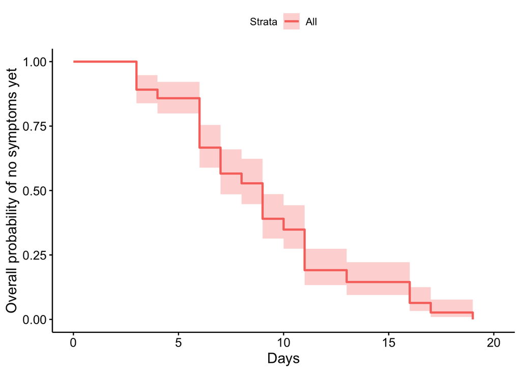

```r
ggsurvplot(
  fit=survfit(Surv(tdata$minIncTimes, tdata$maxIncTimes, type="interval2")~1, data=tdata),
  xlab="Days",
  ylab = "Overall probability of no symptoms yet")
```

The median is about 8 days. For a parametric estimate we remove any remaining NAs and use interval censoring, because we know only that exposure was some time between the minimum and maximum possible values.

```r
reddata=tdata[which(!is.na(tdata$minIncTimes)),]

myfit = ic_par(Surv(reddata$minIncTimes, reddata$maxIncTimes,type="interval2")~1, data = reddata,dist="weibull")


myfit_gamma<- ic_par(Surv(reddata$minIncTimes, reddata$maxIncTimes, type="interval2") ~ 1, data = reddata, dist = "gamma")
summary(myfit_gamma)
```

```
##
## Model:  Cox PH
## Dependency structure assumed: Independence
## Baseline:  gamma
## Call: ic_par(formula = Surv(reddata$minIncTimes, reddata$maxIncTimes,
##     type = "interval2") ~ 1, data = reddata, dist = "gamma")
##
##           Estimate Exp(Est) Std.Error z-value        p
## log_shape    1.491     4.44     0.194    7.68 1.58e-14
## log_scale    0.661     1.94     0.202    3.28 1.05e-03
##
## final llk =  -108
## Iterations =  2
```

```r
myfit_lnorm =  ic_par(Surv(reddata$minIncTimes, reddata$maxIncTimes, type="interval2") ~ 1, data = reddata, dist = "lnorm")
summary(myfit_lnorm)
```

```
##
## Model:  Cox PH
## Dependency structure assumed: Independence
## Baseline:  lnorm
## Call: ic_par(formula = Surv(reddata$minIncTimes, reddata$maxIncTimes,
##     type = "interval2") ~ 1, data = reddata, dist = "lnorm")
##
##       Estimate Exp(Est) Std.Error z-value        p
## mu       2.030    7.615    0.0642   31.63 0.00e+00
## log_s   -0.718    0.487    0.0959   -7.49 7.04e-14
##
## final llk =  -109
## Iterations =  3
```

The log of the shape parameter is 0.83 $\pm$ 0.108, which gives a shape parameter of 2.294 with a 1.96-sd (in the log) giving the range (1.855, 2.836).

If the earliest date of exposure is Dec 1 instead of Dec 31 these are: shape 2.28 (1.8, 2.8), scale 10.0 (8.86, 11.38). If it’s Jan 5 they are shape: 2.28 (1.86, 2.84) and scale 9.79 (8.69, 11.03).

```r
interqs=getFitEsts(myfit, newdata = NULL, p=c(0.025,0.05, 0.25, 0.5, 0.75,0.95,0.975)) #

interqs
```

```
## [1]  1.97  2.68  5.69  8.34 11.29 15.79 17.29
```

```r
interqs_gamma <- getFitEsts(myfit_gamma, newdata=NULL,  p
                      =c(0.025, 0.05, 0.25, 0.5, 0.75, 0.95, 0.975))
interqs_gamma
```

```
## [1]  2.56  3.15  5.62  7.97 10.90 16.23 18.25
```

```r
interqs_lnorm <- getFitEsts(myfit_lnorm, newdata=NULL,  p
                      =c(0.025, 0.05, 0.25, 0.5, 0.75, 0.95, 0.975))
interqs_lnorm
```

```
## [1]  2.93  3.42  5.48  7.62 10.58 16.98 19.80
```

The median is 8.342 days and the 0.95 at 15.791. These are longer than my estimate from the line list data, which matched Backer et al’s analysis of the same data. Here is a plot of the estimated distribution together with the empirical survival curve from the data.

Information for a table for the paper:

```r
# weibull shape scale then quantiles:
c( exp(myfit$coefficients[1]), scale = exp(myfit$coefficients[2])  , getFitEsts(myfit, newdata = NULL, p =c(0.025,  0.5,  0.975)))
```

```
##       log_shape scale.log_scale
##            2.29            9.79            1.97            8.34           17.29
```

```r
# gamma shape, scale then quants
c( shape = exp(myfit_gamma$coefficients[1]), scale = exp(myfit_gamma$coefficients[2]), getFitEsts(myfit_gamma, newdata=NULL,  p =c(0.025,  0.5,  0.975)))
```

```
## shape.log_shape scale.log_scale
##            4.44            1.94            2.56            7.97           18.25
```

```r
# lnorm meanlog, sdlog and quants
c( meanlog = myfit_lnorm$coefficients[1], sdlog = exp(myfit_lnorm$coefficients[2]), getFitEsts(myfit_lnorm, newdata=NULL,  p =c(0.025,  0.5,  0.975)))
```

```
##  meanlog.mu sdlog.log_s
##       2.030       0.488       2.929       7.615      19.801
```

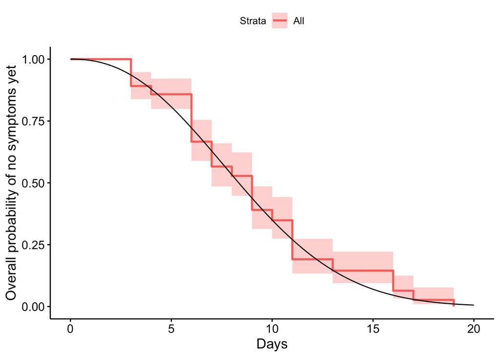

```r
days=seq(0,20,by=0.05)
density=dweibull(days, shape = exp(myfit$coefficients[1]), scale = exp(myfit$coefficients[2]))

ggs = ggsurvplot(
  fit=survfit(Surv(tdata$minIncTimes, tdata$maxIncTimes, type="interval2")~1, data=tdata),
  xlab="Days",  ylab = "Overall probability of no symptoms yet")

pdata <- data.frame(days=rep(days,3),
            fitsurv=c(1-pweibull(days, shape = exp(myfit$coefficients[1]), scale = exp(myfit$coefficients[2])),
        1-pgamma(days,  shape = exp(myfit_gamma$coefficients[1]), scale = exp(myfit_gamma$coefficients[2])),
        1-plnorm(days,  meanlog = myfit_lnorm$coefficients[1], sdlog = exp(myfit_lnorm$coefficients[2]))),distn=c(rep("Weibull", length(days)), rep("Gamma",length(days)), rep("Lognorm", length(days)) ))  # i know, i know...


tmp=data.frame(days=days,  fitsurv=1-pweibull(days, shape = exp(myfit$coefficients[1]),
                      scale = exp(myfit$coefficients[2])))
ggs$plot + geom_line(data = tmp, aes(x = days, y = fitsurv))
```

```r
# ggsave(filename = "inc_Tianjin.pdf", width = 8, height = 6)
```

## Serial interval

We will estimate the serial interval using the ‘interval case to case’ approach given in Vink et al (https://academic.oup.com/aje/article/180/9/865/2739204).

The dataset has quite a few instances where a putative infector or contact is known. These are listed in the ‘Infection_source’ column. We first make a graph in which nodes are individuals and edges are present from cases listed as possible sources, to the cases for whom they are possible sources.

```r
mynodes = tdata$case_id
edges = data.frame(from=mynodes[9],to=mynodes[21],stringsAsFactors = F ) # i read this one manually
for (id in 1:nrow(tdata)) {
tonode=tdata$case_id[id]
fromnodes=str_extract_all(tdata$Infection_source[id], "TJ\\d+", simplify = T)
  if (length(fromnodes)>0) {
    for (k in 1:length(fromnodes)) {
      edges=rbind(edges, c(fromnodes[k], tonode))
    }
  }
}
head(edges)
```

```
##   from   to
## 1  TJ9 TJ21
## 2  TJ6 TJ11
## 3  TJ5 TJ12
## 4  TJ5 TJ13
## 5  TJ5 TJ16
## 6  TJ5 TJ17
```

```r
edges=edges[-1,]
edges=edges[-which(is.na(edges[,1])),] # NAs arose from a few empty entries for Infection_source
```

From this edge list we can use visNetwork to visualise the graph. Colours are from the infection source column (but we should have a better colour scheme, like date of symptom onset).

```r
edges$arrows="to"
nodes = data.frame(id=tdata$case_id, label=tdata$case_id,
                   group=tdata$Infection_source)
visNetwork(nodes,edges)
```

[interactive chart not shown]

The interval case to case (ICC) data are the times between the (presumed) index case for a small cluster and the other cases in the cluster. The Vink et al approach allows these intervals to be one of 4 types, and estimates the serial interval and the probability of each type. To extract ICC intervals, we let the clusters be the components of the graph, and we let the presumed index case be the first to develop symptoms. For each cluster, we subtract the index cases’ symptom time from the symtom times of the rest of the cluster (or just the first few; it turns out that the estimate is not sensitive to this). This results in a list of time intervals between symptom onset in presumed index cases and symptom onset in other cases in the same cluster (graph component).

First construct the graph

```r
#serialdata=edges # REMOVE?
#serialdata$symps_from = tdata$symptom_onset[match(edges$from, tdata$case_id)]
#serialdata$symps_to=tdata$symptom_onset[match(edges$to, tdata$case_id)]
tgraph = graph_from_edgelist(as.matrix(edges[,1:2]), directed = FALSE)
ccs=components(tgraph)

tdata$component=vapply(tdata$case_id, function(x)
  { if (x %in% names(ccs$membership)) { return(ccs$membership[match(x, names(ccs$membership))])
  } else {
    return(NA)}}, FUN.VALUE = 3)
```

Extract ICC interval data

```r
iccdata = 1  # just initialises
stdata = tdata[which(!is.na(tdata$symptom_onset)),]
for (n in 1:max(ccs$membership)) {
  mycases  = which(stdata$component==n)
  myonsets = sort(stdata$symptom_onset[mycases])[1:min(5, length(mycases))]
  iccdata =c(iccdata, myonsets[-1]-myonsets[1])
}
iccdata=iccdata[-1] # remove first initializing entry
iccdata
```

```
##  [1]  1  5  5  8  5  6  9 11  2  8  4  4  7  8  9  4  4  3  2  2 11  6  4  5 10
## [26]  3  0  4  4  4  4  5  6  2  4 18  2  3  4  6  9  2  9 10 11  2 11  3  5  7
## [51]  5
```

Perform the estimate using the Vink et al method, and display the result:

```r
source("TianjinSI_VinkWallinga_CC.R")
myestimate = serial_mix_est(data=iccdata, N=30, startmu=10, startsig =4)
```

```
## [1] 7.23 2.96
## [1] 6.31 2.61
## [1] 5.77 2.39
## [1] 5.38 2.18
## [1] 5.08 1.96
## [1] 4.84 1.74
## [1] 4.66 1.52
## [1] 4.52 1.32
## [1] 4.43 1.18
## [1] 4.38 1.10
## [1] 4.35 1.06
## [1] 4.34 1.04
## [1] 4.33 1.03
## [1] 4.33 1.03
## [1] 4.33 1.03
## [1] 4.33 1.03
## [1] 4.33 1.03
## [1] 4.32 1.03
## [1] 4.32 1.03
## [1] 4.32 1.03
## [1] 4.32 1.03
## [1] 4.32 1.03
## [1] 4.32 1.03
## [1] 4.32 1.03
## [1] 4.32 1.03
## [1] 4.32 1.03
## [1] 4.32 1.03
## [1] 4.32 1.03
## [1] 4.32 1.03
## [1] 4.32 1.03
```

```r
myestimate
```

```
## [1] 4.32 1.03
```

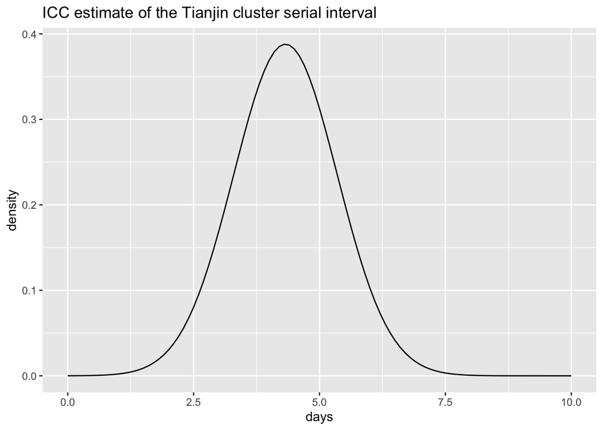

```r
days = seq(from=0, to=10, by=0.1)
density= dnorm(days, mean = myestimate[1], sd = myestimate[2])
ggplot(data=data.frame(days=days, density=density), aes(x=days,y=density)) + geom_line() + ggtitle("ICC estimate of the Tianjin cluster serial interval")
```

Bootstrap

```r
# bootstrap analysis
Nboot=100
bestimates=myestimate
for (kk in 1:Nboot) {
bdata = sample(x=iccdata, size = length(iccdata), replace = T)
bestimates = rbind(bestimates, serial_mix_est(data=bdata, N=50, startmu=10, startsig =4))
}
```

[output not shown]

[output cut: 4985 more lines]

```r
mean(bestimates[,1]) # mean of the mean serial intervals
```

```
## [1] 4.44
```

```r
mean(bestimates[,2]) # sd of the sd serial intervals
```

```
## [1] 1.06
```

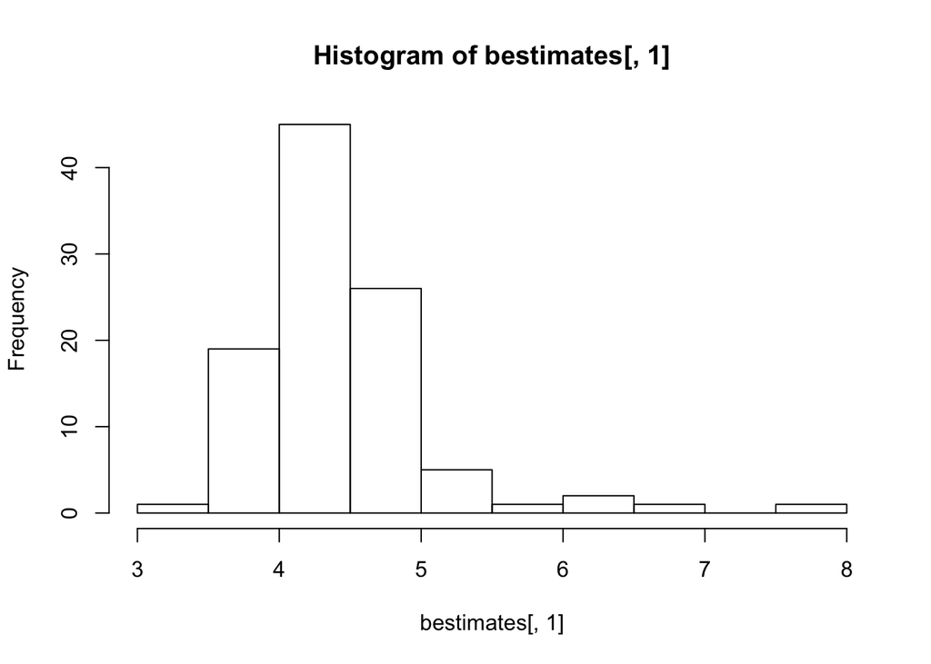

```r
hist(bestimates[,1],breaks = 10)
```

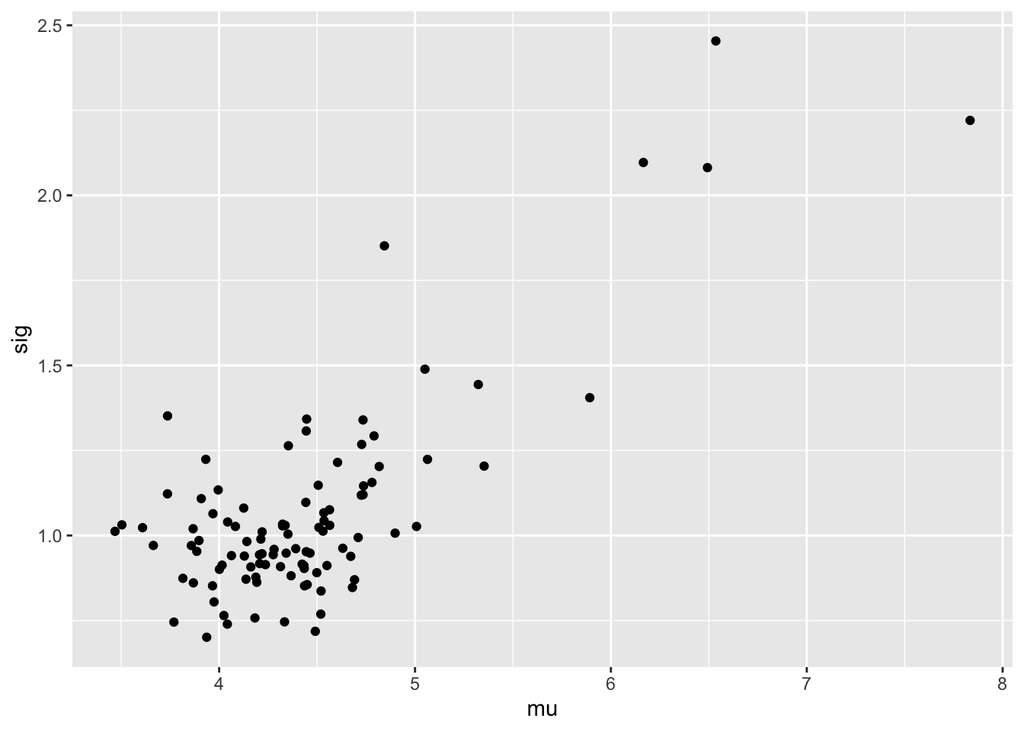

```r
bootdf=data.frame(mu=bestimates[,1], sig=bestimates[,2])
ggplot(bootdf, aes(x=mu, y=sig))+geom_point()
```

```r
mean(bestimates[,1]) # higher estimates also have high uncertainty
```

```
## [1] 4.44
```